# Binary Response (ELMR Chapter 2)

Biostat 200C

Author

Dr. Jin Zhou @ UCLA

Published

April 9, 2026

Display system information and load `tidyverse` and `faraway` packages

```r
library(tidyverse)
library(faraway)
```

`faraway` package contains the datasets in the ELMR book.

## 1 Heart disease example

The dataframe `wcgs` in `faraway` package contains data from the Western Collaborative Group Study.

```r
wcgs %>% head(10)
```

```
   age height weight sdp dbp chol behave cigs dibep chd  typechd timechd
1   49     73    150 110  76  225     A2   25     A  no     none    1664
2   42     70    160 154  84  177     A2   20     A  no     none    3071
3   42     69    160 110  78  181     B3    0     B  no     none    3071
4   41     68    152 124  78  132     B4   20     B  no     none    3064
5   59     70    150 144  86  255     B3   20     B yes infdeath    1885
6   44     72    204 150  90  182     B4    0     B  no     none    3102
7   44     72    164 130  84  155     B4    0     B  no     none    3074
8   40     71    150 138  60  140     A2    0     A  no     none    3071
9   43     72    190 146  76  149     B3   25     B  no     none    3064
10  42     70    175 132  90  325     A2    0     A  no     none    1032
     arcus
1   absent
2  present
3   absent
4   absent
5  present
6   absent
7   absent
8   absent
9   absent
10 present
```

We convert the dataframe into a tibble for compatibility with tidyverse.

```r
wcgs <- wcgs %>%
  as_tibble() %>%
  print(width = Inf)
```

```
# A tibble: 3,154 × 13
     age height weight   sdp   dbp  chol behave  cigs dibep chd   typechd
   <int>  <int>  <int> <int> <int> <int> <fct>  <int> <fct> <fct> <fct>
 1    49     73    150   110    76   225 A2        25 A     no    none
 2    42     70    160   154    84   177 A2        20 A     no    none
 3    42     69    160   110    78   181 B3         0 B     no    none
 4    41     68    152   124    78   132 B4        20 B     no    none
 5    59     70    150   144    86   255 B3        20 B     yes   infdeath
 6    44     72    204   150    90   182 B4         0 B     no    none
 7    44     72    164   130    84   155 B4         0 B     no    none
 8    40     71    150   138    60   140 A2         0 A     no    none
 9    43     72    190   146    76   149 B3        25 B     no    none
10    42     70    175   132    90   325 A2         0 A     no    none
   timechd arcus
     <int> <fct>
 1    1664 absent
 2    3071 present
 3    3071 absent
 4    3064 absent
 5    1885 present
 6    3102 absent
 7    3074 absent
 8    3071 absent
 9    3064 absent
10    1032 present
# ℹ 3,144 more rows
```

For now, we focus just on variables  
- `chd`, whether the person develops coronary heart disease or not,  
- `height`, height of the person in inches,  
- `cigs`, number of cigarettes smoked per day.

```r
wcgs %>%
  select(chd, height, cigs) %>%
  summary()
```

```
  chd           height           cigs
 no :2897   Min.   :60.00   Min.   : 0.0
 yes: 257   1st Qu.:68.00   1st Qu.: 0.0
            Median :70.00   Median : 0.0
            Mean   :69.78   Mean   :11.6
            3rd Qu.:72.00   3rd Qu.:20.0
            Max.   :78.00   Max.   :99.0
```

We use side-by-side boxplots to summarize the qulitative variable `chd` and quantitative variables `height` and `cigs`

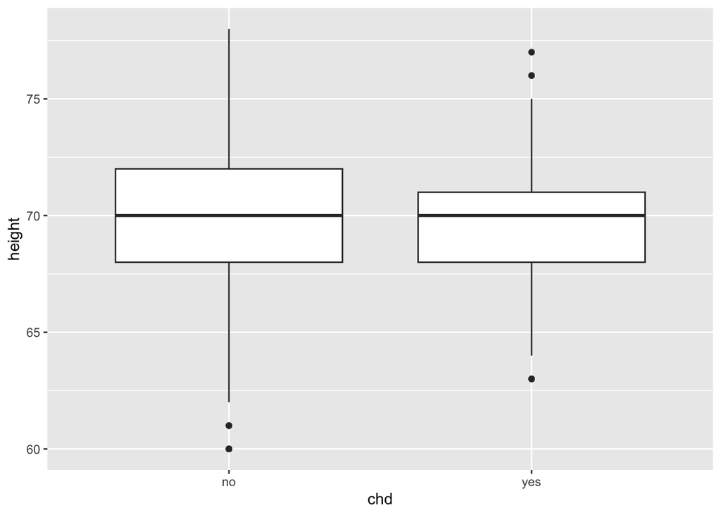

```r
ggplot(data = wcgs) +
  geom_boxplot(mapping = aes(x = chd, y = height))
```

and number of cigarretes smoked per day

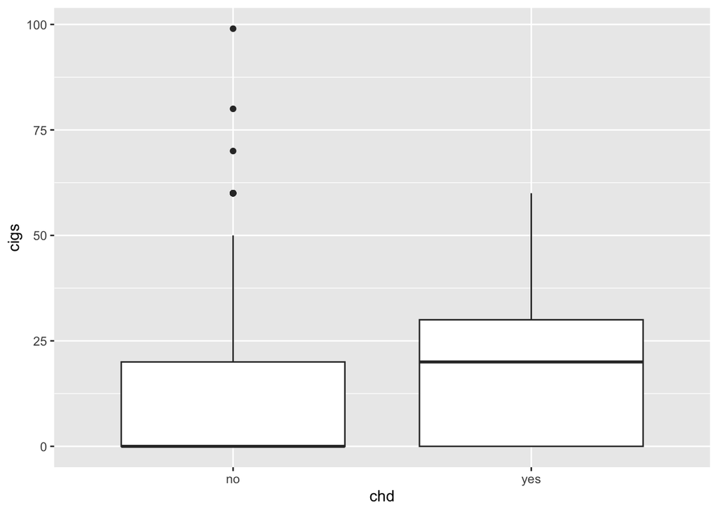

```r
ggplot(data = wcgs) +
  geom_boxplot(mapping = aes(x = chd, y = cigs))
```

It seems more cigarettes is associated with heard disease, but not height. How can we formally analyze this? If we use linear regression (straight line) for the anlaysis, the line will eventually extends beyond the [0, 1] range, making interpretation hard.

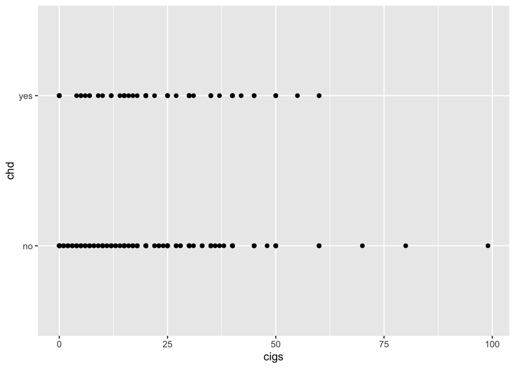

```r
ggplot(data = wcgs) +
  geom_point(mapping = aes(x = cigs, y = chd))
```

## 2 Logistic regression

- Bernoulli model for a binary response
  $$Y_i = \begin{cases}
  1 & \text{with probability } p_i \\
  0 & \text{with probability } 1 - p_i
  \end{cases}$$
- The parameter $p_i = \mathbb{E}(Y_i)$ will be related to the predictors $X_1, \ldots, X_{q}$ via an **inverse link function**
  $$p_i = \frac{e^{\eta_i}}{1 + e^{\eta_i}},$$
  where $\eta_i$ is the **linear predictor** or **systematic component**
  $$\eta_i = \beta_0 + \beta_1 x_{i1} + \cdots + \beta_{q} x_{iq} = \mathbf{x}_i^T \boldsymbol{\beta}$$
  with
  $$\boldsymbol{\beta} = \begin{pmatrix} \beta_0 \\ \beta_1 \\ \vdots \\ \beta_q \end{pmatrix}, \quad \mathbf{x}_i = \begin{pmatrix} 1 \\ x_{i1} \\ \vdots \\ x_{iq} \end{pmatrix}.$$
- The function
  $$\eta = g(p) = \log \left( \frac{p}{1-p} \right)$$
  that links $\mathbb{E}(Y)$ to the systematic component is called the **link function**. This particular link function is also called the **logit function**.
- The function
  $$p = g^{-1}(\eta) = \frac{e^\eta}{1 + e^\eta}$$
  is called the **inverse link function**. This particular function (inverse logit) is also called the **logistic function**. A graph of the logistic function:

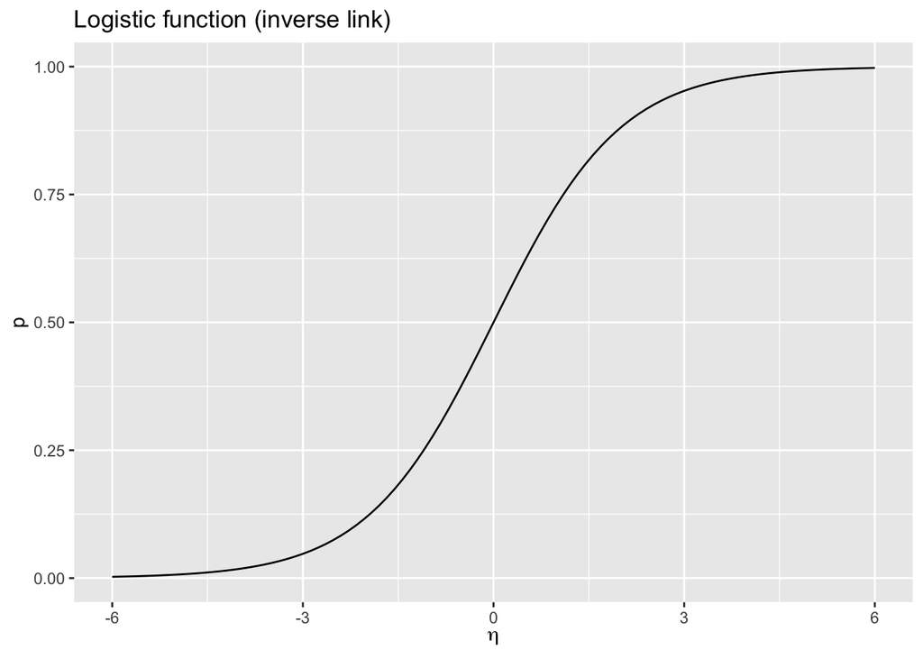

```r
ggplot(data = tibble(x = 0), mapping = aes(x = x)) + # null data
  stat_function(fun = ilogit) + # ilogit is from faraway
  xlim(-6, 6) +
  labs(x = expression(eta), y = "p", title = "Logistic function (inverse link)")
```

```r
# curve(ilogit(x), -6, 6, xlab = expression(eta), ylab = "p")
```

- Therefore above model is called the **logistic regression**.

## 3 Fitting logistic regression

- We use **method of maximum likelihood** (MLE) to estimate the parameters $\beta_0, \ldots, \beta_q$.
- Given $n$ data points $(y_i, \mathbf{x}_i)$, $i=1,\ldots,n$, the **log-likelihood** is
  $$\begin{eqnarray*}
  \ell(\boldsymbol{\beta}) &=& \sum_i \log \left[p_i^{y_i} (1 - p_i)^{1 - y_i}\right] \\
  &=& \sum_i \left[ y_i \log p_i + (1 - y_i) \log (1 - p_i) \right] \\
  &=& \sum_i \left[ y_i \log \frac{e^{\eta_i}}{1 + e^{\eta_i}} + (1 - y_i) \log \frac{1}{1 + e^{\eta_i}} \right] \\
  &=& \sum_i \left[ y_i \eta_i - \log (1 + e^{\eta_i}) \right] \\
  &=& \sum_i \left[ y_i \cdot \mathbf{x}_i^T \boldsymbol{\beta} - \log (1 + e^{\mathbf{x}_i^T \boldsymbol{\beta}}) \right].
  \end{eqnarray*}$$
  HW1 Bonus: show that the log-likelihood function of logistic regression is a concave function in $\boldsymbol{\beta}$.
- Maximization of this log-likelihood function can be carried out by the Newton-Raphson (also known as Fisher scoring) algorithm.

```r
(lmod <- glm(chd ~ height + cigs, family = binomial, wcgs))
```

```
Call:  glm(formula = chd ~ height + cigs, family = binomial, data = wcgs)

Coefficients:
(Intercept)       height         cigs
   -4.50161      0.02521      0.02313

Degrees of Freedom: 3153 Total (i.e. Null);  3151 Residual
Null Deviance:      1781
Residual Deviance: 1749     AIC: 1755
```

Inspect the content in the result `lmod`:

```r
str(lmod)
```

```
List of 30
 $ coefficients     : Named num [1:3] -4.5016 0.0252 0.0231
  ..- attr(*, "names")= chr [1:3] "(Intercept)" "height" "cigs"
 $ residuals        : Named num [1:3154] -1.12 -1.1 -1.06 -1.1 10.72 ...
  ..- attr(*, "names")= chr [1:3154] "1" "2" "3" "4" ...
 $ fitted.values    : Named num [1:3154] 0.1107 0.0933 0.0594 0.0891 0.0933 ...
  ..- attr(*, "names")= chr [1:3154] "1" "2" "3" "4" ...
 $ effects          : Named num [1:3154] 36.178 -1.071 5.724 -0.312 3.124 ...
  ..- attr(*, "names")= chr [1:3154] "(Intercept)" "height" "cigs" "" ...
 $ R                : num [1:3, 1:3] -15.3 0 0 -1068.1 -38 ...
  ..- attr(*, "dimnames")=List of 2
  .. ..$ : chr [1:3] "(Intercept)" "height" "cigs"
  .. ..$ : chr [1:3] "(Intercept)" "height" "cigs"
 $ rank             : int 3
 $ qr               :List of 5
  ..$ qr   : num [1:3154, 1:3] -15.276 0.019 0.0155 0.0186 0.019 ...
  .. ..- attr(*, "dimnames")=List of 2
  .. .. ..$ : chr [1:3154] "1" "2" "3" "4" ...
  .. .. ..$ : chr [1:3] "(Intercept)" "height" "cigs"
  ..$ rank : int 3
  ..$ qraux: num [1:3] 1.02 1 1.02
  ..$ pivot: int [1:3] 1 2 3
  ..$ tol  : num 1e-11
  ..- attr(*, "class")= chr "qr"
 $ family           :List of 13
  ..$ family    : chr "binomial"
  ..$ link      : chr "logit"
  ..$ linkfun   :function (mu)
  ..$ linkinv   :function (eta)
  ..$ variance  :function (mu)
  ..$ dev.resids:function (y, mu, wt)
  ..$ aic       :function (y, n, mu, wt, dev)
  ..$ mu.eta    :function (eta)
  ..$ initialize: language {     if (NCOL(y) == 1) { ...
  ..$ validmu   :function (mu)
  ..$ valideta  :function (eta)
  ..$ simulate  :function (object, nsim)
  ..$ dispersion: num 1
  ..- attr(*, "class")= chr "family"
 $ linear.predictors: Named num [1:3154] -2.08 -2.27 -2.76 -2.32 -2.27 ...
```

[output cut: 58 more lines]

```
  ..$ cigs   : int [1:3154] 25 20 0 20 20 0 0 0 25 0 ...
  ..$ dibep  : Factor w/ 2 levels "A","B": 1 1 2 2 2 2 2 1 2 1 ...
  ..$ chd    : Factor w/ 2 levels "no","yes": 1 1 1 1 2 1 1 1 1 1 ...
  ..$ typechd: Factor w/ 4 levels "angina","infdeath",..: 3 3 3 3 2 3 3 3 3 3 ...
  ..$ timechd: int [1:3154] 1664 3071 3071 3064 1885 3102 3074 3071 3064 1032 ...
  ..$ arcus  : Factor w/ 2 levels "absent","present": 1 2 1 1 2 1 1 1 1 2 ...
 $ offset           : NULL
 $ control          :List of 3
  ..$ epsilon: num 1e-08
  ..$ maxit  : num 25
  ..$ trace  : logi FALSE
 $ method           : chr "glm.fit"
 $ contrasts        : NULL
 $ xlevels          : Named list()
 - attr(*, "class")= chr [1:2] "glm" "lm"
```

Summary of the result:

```r
(lmod_sm <- summary(lmod))
```

```
Call:
glm(formula = chd ~ height + cigs, family = binomial, data = wcgs)

Coefficients:
            Estimate Std. Error z value Pr(>|z|)
(Intercept) -4.50161    1.84186  -2.444   0.0145 *
height       0.02521    0.02633   0.957   0.3383
cigs         0.02313    0.00404   5.724 1.04e-08 ***
---
Signif. codes:  0 '***' 0.001 '**' 0.01 '*' 0.05 '.' 0.1 ' ' 1

(Dispersion parameter for binomial family taken to be 1)

    Null deviance: 1781.2  on 3153  degrees of freedom
Residual deviance: 1749.0  on 3151  degrees of freedom
AIC: 1755

Number of Fisher Scoring iterations: 5
```

```r
str(lmod_sm)
```

```
List of 17
 $ call          : language glm(formula = chd ~ height + cigs, family = binomial, data = wcgs)
 $ terms         :Classes 'terms', 'formula'  language chd ~ height + cigs
  .. ..- attr(*, "variables")= language list(chd, height, cigs)
  .. ..- attr(*, "factors")= int [1:3, 1:2] 0 1 0 0 0 1
  .. .. ..- attr(*, "dimnames")=List of 2
  .. .. .. ..$ : chr [1:3] "chd" "height" "cigs"
  .. .. .. ..$ : chr [1:2] "height" "cigs"
  .. ..- attr(*, "term.labels")= chr [1:2] "height" "cigs"
  .. ..- attr(*, "order")= int [1:2] 1 1
  .. ..- attr(*, "intercept")= int 1
  .. ..- attr(*, "response")= int 1
  .. ..- attr(*, ".Environment")=<environment: R_GlobalEnv>
  .. ..- attr(*, "predvars")= language list(chd, height, cigs)
  .. ..- attr(*, "dataClasses")= Named chr [1:3] "factor" "numeric" "numeric"
  .. .. ..- attr(*, "names")= chr [1:3] "chd" "height" "cigs"
 $ family        :List of 13
  ..$ family    : chr "binomial"
  ..$ link      : chr "logit"
  ..$ linkfun   :function (mu)
  ..$ linkinv   :function (eta)
  ..$ variance  :function (mu)
  ..$ dev.resids:function (y, mu, wt)
  ..$ aic       :function (y, n, mu, wt, dev)
  ..$ mu.eta    :function (eta)
  ..$ initialize: language {     if (NCOL(y) == 1) { ...
  ..$ validmu   :function (mu)
  ..$ valideta  :function (eta)
  ..$ simulate  :function (object, nsim)
  ..$ dispersion: num 1
  ..- attr(*, "class")= chr "family"
 $ deviance      : num 1749
 $ aic           : num 1755
 $ contrasts     : NULL
 $ df.residual   : int 3151
 $ null.deviance : num 1781
 $ df.null       : int 3153
 $ iter          : int 5
 $ deviance.resid: Named num [1:3154] -0.484 -0.442 -0.35 -0.432 2.178 ...
  ..- attr(*, "names")= chr [1:3154] "1" "2" "3" "4" ...
 $ coefficients  : num [1:3, 1:4] -4.5016 0.0252 0.0231 1.8419 0.0263 ...
  ..- attr(*, "dimnames")=List of 2
  .. ..$ : chr [1:3] "(Intercept)" "height" "cigs"
  .. ..$ : chr [1:4] "Estimate" "Std. Error" "z value" "Pr(>|z|)"
 $ aliased       : Named logi [1:3] FALSE FALSE FALSE
  ..- attr(*, "names")= chr [1:3] "(Intercept)" "height" "cigs"
 $ dispersion    : num 1
 $ df            : int [1:3] 3 3151 3
 $ cov.unscaled  : num [1:3, 1:3] 3.392458 -0.048431 -0.000114 -0.048431 0.000693 ...
  ..- attr(*, "dimnames")=List of 2
  .. ..$ : chr [1:3] "(Intercept)" "height" "cigs"
  .. ..$ : chr [1:3] "(Intercept)" "height" "cigs"
 $ cov.scaled    : num [1:3, 1:3] 3.392458 -0.048431 -0.000114 -0.048431 0.000693 ...
  ..- attr(*, "dimnames")=List of 2
  .. ..$ : chr [1:3] "(Intercept)" "height" "cigs"
  .. ..$ : chr [1:3] "(Intercept)" "height" "cigs"
 - attr(*, "class")= chr "summary.glm"
```

## 4 Interpretation

- **Exercise**: Before we attempt to interpret the results from logistic regression, we first need to understand how the data is transformed to $(y_i, \mathbf{x}_i)$.

```r
# dataframe
wcgs %>%
  select(chd, height, cigs) %>%
  head(10)
```

```
# A tibble: 10 × 3
   chd   height  cigs
   <fct>  <int> <int>
 1 no        73    25
 2 no        70    20
 3 no        69     0
 4 no        68    20
 5 yes       70    20
 6 no        72     0
 7 no        72     0
 8 no        71     0
 9 no        72    25
10 no        70     0
```

```r
# response
lmod$y %>% head(10)
```

```
 1  2  3  4  5  6  7  8  9 10
 0  0  0  0  1  0  0  0  0  0
```

```r
# predictors
model.matrix(lmod) %>% head(10)
```

```
   (Intercept) height cigs
1            1     73   25
2            1     70   20
3            1     69    0
4            1     68   20
5            1     70   20
6            1     72    0
7            1     72    0
8            1     71    0
9            1     72   25
10           1     70    0
```

- How to interpret the regression coefficients in logistic regression? Remember
  $$\log \left( \frac{p}{1-p} \right) = \beta_0 + \beta_1 \cdot \text{height} + \beta_2 \cdot \text{cigs}.$$
  The quantity
  $$o = \frac{p}{1-p}$$
  is called **odds** (of an event).

  Therefore $\beta_1$ can be interpreted as a unit increase in $x_1$ with $x_2$ held fixed increases the **log-odds** of success by $\beta_1$, or increase the odds of success by a factor of $e^{\beta_1}$.
- The `gtsummary` package presents regression results in a much nicer way that facilitates interpretation. Summarize the log-odds:

```r
library(gtsummary)
lmod %>%
  tbl_regression() %>%
  bold_labels() %>%
  bold_p(t = 0.05)
```

| **Characteristic** | **log(OR)** | **95% CI** | **p-value** |
| --- | --- | --- | --- |
| height | 0.03 | -0.03, 0.08 | 0.3 |
| cigs | 0.02 | 0.02, 0.03 | <0.001 |

Abbreviations: CI = Confidence Interval, OR = Odds Ratio

Summarize the odds:

```r
lmod %>%
  tbl_regression(intercept = TRUE, exponentiate = TRUE) %>%
  bold_labels() %>%
  bold_p(t = 0.05)
```

| **Characteristic** | **OR** | **95% CI** | **p-value** |
| --- | --- | --- | --- |
| (Intercept) | 0.01 | 0.00, 0.40 | 0.015 |
| height | 1.03 | 0.97, 1.08 | 0.3 |
| cigs | 1.02 | 1.02, 1.03 | <0.001 |

Abbreviations: CI = Confidence Interval, OR = Odds Ratio

- **Exercise**: Interpret the regression coefficients from `wcgs` fit.

```r
# same as lmod$coefficients
# coef(lmod) is a named numeric vector
(beta_hat <- unname(coef(lmod)))
```

```
[1] -4.50161397  0.02520779  0.02312740
```

```r
exp(beta_hat)
```

```
[1] 0.01109108 1.02552819 1.02339691
```

How to interpret the effect of a pack a day (20 cigarettes) on heart disease?

```r
exp(beta_hat[3] * 20)
```

```
[1] 1.588115
```

- Suppose the probability of success in the presence of some condition is $p_1$ and $p_2$ in its absence. The **relative risk** or **risk ratio** is $p_1 / p_2$. For example, the predicted probability of a 68in tall person who smokes a pack (20 cigarettes) a day and who does not smoke are, respectively

```r
(p1 <- ilogit(sum(beta_hat * c(1, 68, 20))))
```

```
[1] 0.08907868
```

and

```r
(p2 <- ilogit(sum(beta_hat * c(1, 68, 0))))
```

```
[1] 0.05800425
```

Then the relative risk is

```r
p1 / p2
```

```
[1] 1.535727
```

- When the probability of event is very small (rare disease assumption), i.e., $p_1, p_2 \approx 0$, then the odds ratio is approximately equal to the risk ratio
  $$\frac{o_1}{o_2} = \frac{p_1 / (1 - p_1)}{p_2 / (1 - p_2)} \approx \frac{p_1}{p_2}.$$

## 5 Inference (analysis of deviance)

- The **deviance** is defined as the difference of likelihoods between the fitted model and the saturated model (perfect fit model).
  $$\begin{eqnarray*}
  D &=& -2\log lik(\hat \beta) + 2 \log lik (\text{saturated model)}
  \end{eqnarray*}$$
  It comes from the likelihood ratio test (LRT) statistic
  $$2 \log \frac{L_{\Omega}}{L_{\omega}},$$
  where $\Omega$ is the full/saturated model (same number of parameters as observations) and $\omega$ is the smaller model.
- The **deviance** of a logistic regression fit is
  $$\begin{eqnarray*}
  D &=& 2 \sum_i \left[ y_i \log y_i + (1 - y_i) \log (1 - y_i) \right] \\
  && - 2 \sum_i \left[ y_i \log \widehat{p}_i + (1 - y_i) \log (1 - \widehat{p}_i) \right] \\
  &=& - 2 \sum_i \left[ y_i \log \widehat{p}_i + (1 - y_i) \log (1 - \widehat{p}_i) \right].
  \end{eqnarray*}$$
- The usual goodness of fit test using $\chi_{n-q-1}^2$ asymptotic null distribution can **not** be applied here since we only have a single observation for each predictor pattern. This is different from the binomial model in next chapter. The Hosmer-Lemeshow test partitions the predicted probailities into $J$ bins and then carries out a Pearson $X^2$ type test to assess the goodness of fit (ELMR 2.6).
- In the model output, the **residual deviance**, denoted $D_L$, is the devience of the current model and the *null deviance*, denoted $D_S$, is the deviance of the model with just an intercept term. Assuming the null model, the test statistic $D_S - D_L$ is asymptotically distributed $\chi_{\ell - s}^2$. In our case, the test statistic is

```r
lmod$null.deviance - lmod$deviance
```

```
[1] 32.19451
```

giving p-value

```r
pchisq(lmod$null.deviance - lmod$deviance, 2, lower.tail = FALSE)
```

```
[1] 1.02106e-07
```

Therefore our model gives a significantly better fit than the null (intercept-only) model.

- We can also test the significance of individual predictor using analysis of deviance (`anova` function). For example, is `height` necessary in the model?

```r
# fit a model without height
lmodc <- glm(chd ~ cigs, family = binomial, wcgs)
anova(lmodc, lmod, test = "Chi")
```

```
Analysis of Deviance Table

Model 1: chd ~ cigs
Model 2: chd ~ height + cigs
  Resid. Df Resid. Dev Df Deviance Pr(>Chi)
1      3152       1750
2      3151       1749  1  0.92025   0.3374
```

- Similar to linear regression, the convenience function `drop1` tests each individual predictor in one shot.

```r
drop1(lmod, test = "Chi")
```

```
Single term deletions

Model:
chd ~ height + cigs
       Df Deviance    AIC     LRT Pr(>Chi)
<none>      1749.0 1755.0
height  1   1750.0 1754.0  0.9202   0.3374
cigs    1   1780.1 1784.1 31.0695 2.49e-08 ***
---
Signif. codes:  0 '***' 0.001 '**' 0.01 '*' 0.05 '.' 0.1 ' ' 1
```

- The coefficient test from summary is based on the z-value $\hat \beta_j / \text{se}(\hat{\beta}_j)$.

```r
lmod_sm$coefficients
```

```
               Estimate  Std. Error   z value     Pr(>|z|)
(Intercept) -4.50161397 1.841862743 -2.444055 1.452321e-02
height       0.02520779 0.026327385  0.957474 3.383281e-01
cigs         0.02312740 0.004040183  5.724344 1.038339e-08
```

In general, deviance-based test is preferred over the z-test.

## 6 Confidence intervals

- Confidence interval can be constructed either from normal approximation
  $$\hat \beta_j \pm z^{\alpha / 2} \text{se}(\hat \beta_j)$$

```r
tibble(
  `coef`  = beta_hat,
  `2.5%`  = beta_hat - 1.96 * lmod_sm$coefficients[, 2],
  `97.5%` = beta_hat + 1.96 * lmod_sm$coefficients[, 2])
```

```
# A tibble: 3 × 3
     coef  `2.5%` `97.5%`
    <dbl>   <dbl>   <dbl>
1 -4.50   -8.11   -0.892
2  0.0252 -0.0264  0.0768
3  0.0231  0.0152  0.0310
```

or from profile-likelihood

```r
confint(lmod)
```

```
                  2.5 %      97.5 %
(Intercept) -8.13475465 -0.91297018
height      -0.02619902  0.07702835
cigs         0.01514949  0.03100534
```

## 7 Diagnostics

- There are two kinds of fitted values (or predicted values). The first is on the scale of the linear predictor, $\eta$,

```r
linpred  <- predict(lmod)
linpred %>% head(10)
```

```
        1         2         3         4         5         6         7         8
-2.083261 -2.274521 -2.762277 -2.324936 -2.274521 -2.686653 -2.686653 -2.711861
        9        10
-2.108468 -2.737069
```

The second on the scale of response, $p = \text{logit}^{-1}(\eta)$,

```r
predprob <- predict(lmod, type = "response")
predprob %>% head(10)
```

```
         1          2          3          4          5          6          7
0.11073449 0.09325523 0.05939705 0.08907868 0.09325523 0.06376553 0.06376553
         8          9         10
0.06227708 0.10827647 0.06082112
```

- We compute the **raw residuals**
  $$y - \widehat{p}$$

```r
# same as residuals(lmod, type = "response")
rawres <- lmod$y - predprob
```

The plot of raw residuals against the fitted values is not very informative.

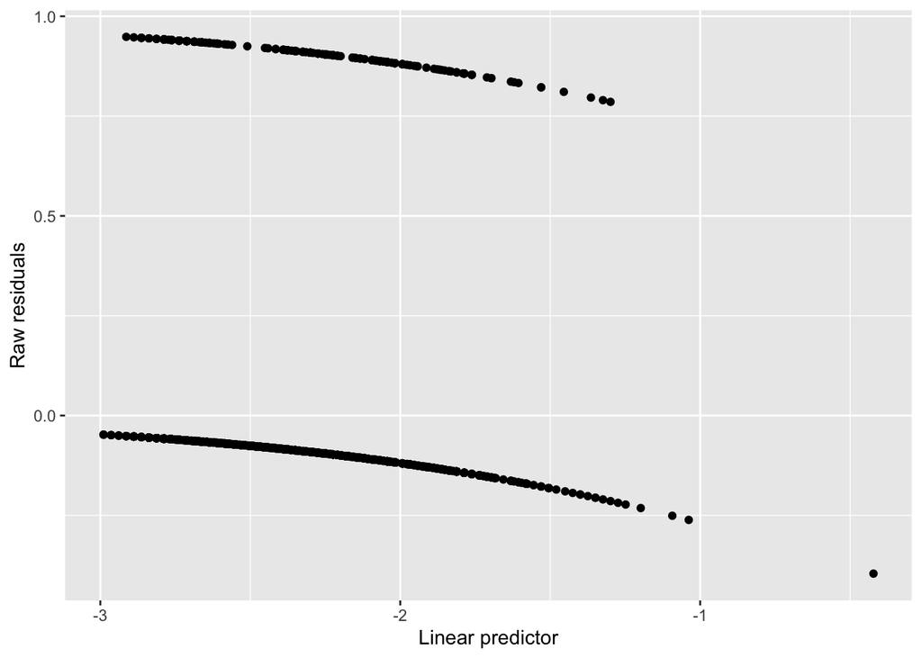

```r
wcgs %>%
  mutate(rawres = rawres, linpred = linpred) %>%
  ggplot() +
  geom_point(mapping = aes(x = linpred, y = rawres)) +
  labs(x = "Linear predictor", y = "Raw residuals")
```

We do not expect the raw residuals to have equal variance because the binary variance is $p(1 - p)$.

- The **deviance residuals** are standardized residuals defined by
  $$d_i = \text{sign}(y_i - \widehat{p}_i) \sqrt{-2 [y_i \log\widehat{p}_i + (1 - y_i) \log(1 - \widehat{p}_i)]}.$$
  Note
  $$\sum_i d_i^2 = \text{deviance}$$
  in analogy to $\sum_i \widehat{\epsilon}_i^2 = \text{RSS}$ in linear regression. The term $\text{sign}(y_i - \widehat{p}_i)$ ensures that $d_i$ has the same sign as raw residual $y_i - \widehat{p}_i$.

```r
devres <- residuals(lmod)
devres %>% head(10)
```

```
         1          2          3          4          5          6          7
-0.4844779 -0.4424800 -0.3499548 -0.4319693  2.1782631 -0.3630133 -0.3630133
         8          9         10
-0.3586106 -0.4787466 -0.3542579
```

Sanity check:

```r
sqrt(-2 * (lmod$y * log(predprob) + (1 - lmod$y) * log(1 - predprob))) %>%
  head(10)
```

```
        1         2         3         4         5         6         7         8
0.4844779 0.4424800 0.3499548 0.4319693 2.1782631 0.3630133 0.3630133 0.3586106
        9        10
0.4787466 0.3542579
```

The plot of deviance residuals against the fitted values.

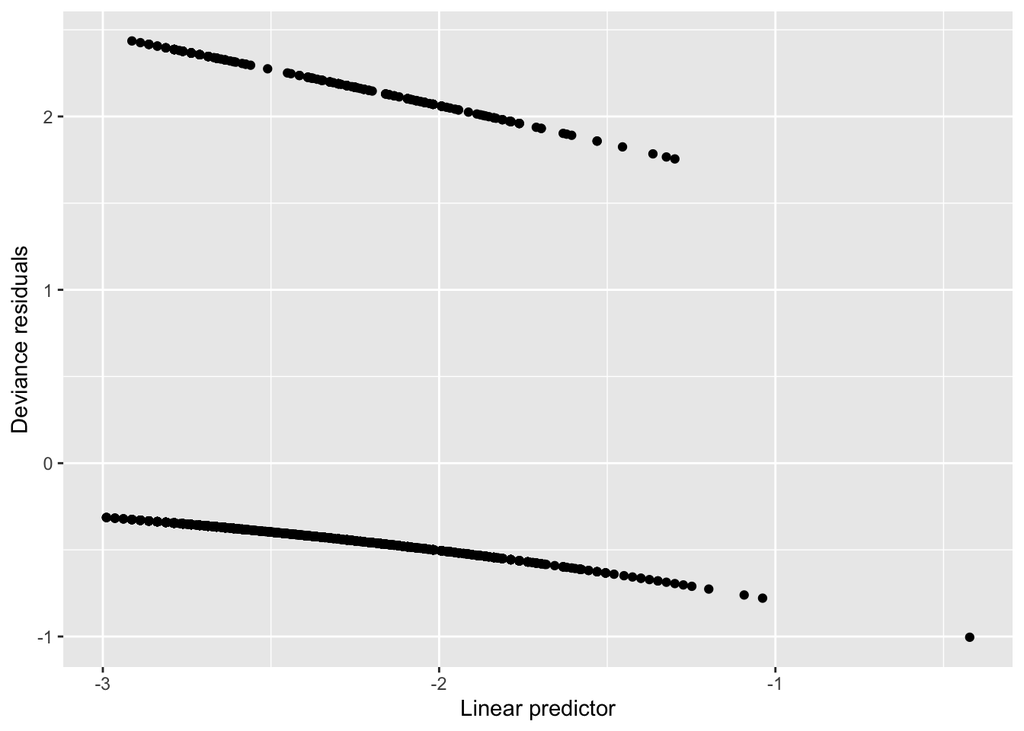

```r
wcgs %>%
  mutate(devres = devres, linpred = linpred) %>%
  ggplot() +
  geom_point(mapping = aes(x = linpred, y = devres)) +
  labs(x = "Linear predictor", y = "Deviance residuals")
```

Again we see the residuals are clustered into two lines: the upper one corresponding to $y_i=1$ and the lower one to $y_i=0$. We can improve this plot by binning: divide the range of linear predictor into 100 bins of roughly equal points and plot average residual against average linear predictors per bin.

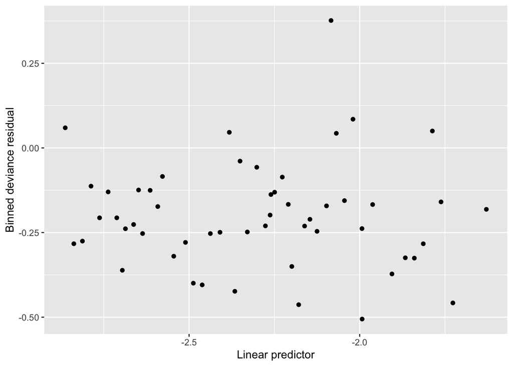

```r
wcgs %>%
  mutate(devres = devres, linpred = linpred) %>%
  group_by(cut(linpred, breaks = unique(quantile(linpred, (1:100)/101)))) %>%
  summarize(devres = mean(devres),
            linpred = mean(linpred)) %>%
  ggplot() +
  geom_point(mapping = aes(x = linpred, y = devres)) +
  labs(x = "Linear predictor", y = "Binned deviance residual")
```

- What this plot tells us is there is no obvious association between the deviance residuals and the linear predictor. If there is a pattern, it suggests that the model is not correctly specified. We may need to add more predictors or transform the existing predictors.

**Question**: is there a concern that the deviance residuals are not centered around 0?

- **Exercise**: Do similar binned plots for deviance residuals against `height` and deviance residuals vs `cigs` to check the linearity assumption.

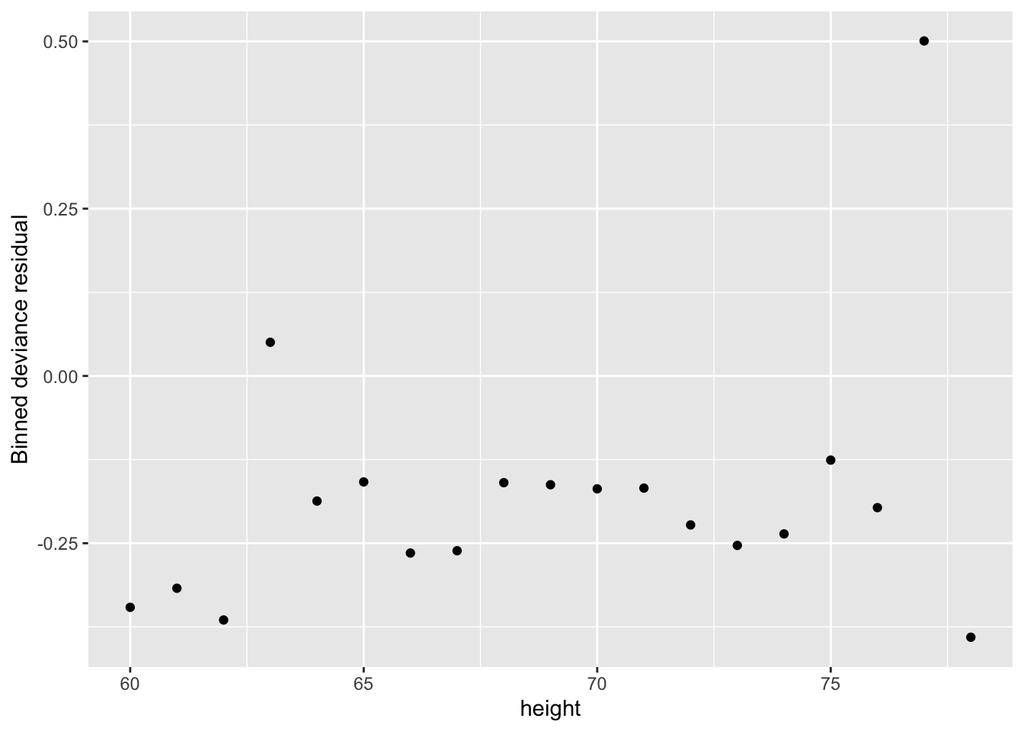

```r
wcgs %>%
  mutate(devres = devres) %>%
  group_by(height) %>%
  summarize(devres = mean(devres)) %>%
  ggplot() +
  geom_point(mapping = aes(x = height, y = devres)) +
  labs(x = "height", y = "Binned deviance residual")
```

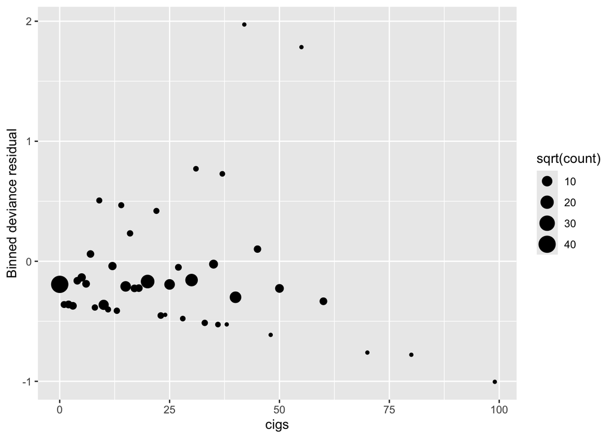

```r
wcgs %>%
  mutate(devres = devres) %>%
  group_by(cigs) %>%
  summarize(devres = mean(devres),
            count = n()) %>%
  ggplot() +
  geom_point(mapping = aes(x = cigs, y = devres, size=sqrt(count))) +
  labs(x = "cigs", y = "Binned deviance residual")
```

- **Previous year’s bonus exercise**: Simulate data for a logistic regression model with a quadratic term (e.g., $X_1^2$) as the true model and check the linearity assumption using the following plots:
  - Binned deviance residuals against linear predictor $X_1$ when you model the systematic component as a linear function of the predictors
  - Binned deviance residuals against the quadratic term $X_1^2$ when you model the systematic component as a quadratic function of the predictors
  - Binned deviance residuals against fitted value ($\hat\eta$) when you model the systematic component as a quadratic function of the predictors
  - Binned deviance residuals against fitted value ($\hat\eta$) when you model the systematic component as a linear function of the predictors
  - Scatter plot of logit(binned $Y$) and $X_1^2$: break the range of $X1$ into bins, and within each bin, calculate the mean value of $X1$ and $Y$ for observations in that bin. We then transform the mean of $Y$ through the link function
  - Scatter plot of logit(binned $Y$) and $\hat\eta$
  - Scatter plot of logit(binned $Y$) and $X_1$
- QQ plot is not helpful since there is no reason these deviance residuals are approximately standard normal.

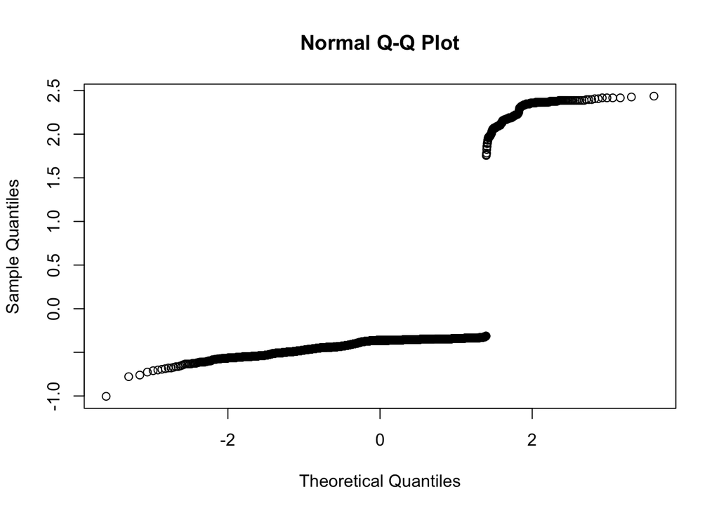

```r
qqnorm(devres)
```

- Half-normal plot (hat values against half-normal quantiles) can help detect unusual cases in predictor space (high leverage cases). For logistic regression, we use the generalized hat matrix
  $$\mathbf{H} = \widehat{\mathbf{W}}^{1/2} \mathbf{X}^T (\mathbf{X}^T \widehat{\mathbf{W}} \mathbf{X})^{-1} \mathbf{X} \widehat{\mathbf{W}}^{1/2},$$
  where
  $$\widehat{\mathbf{W}} = \begin{pmatrix}
  \widehat{p}_1 (1 - \widehat{p}_1) & \\
  & \ddots & \\
  & & \widehat{p}_n (1 - \widehat{p}_n)
  \end{pmatrix}.$$

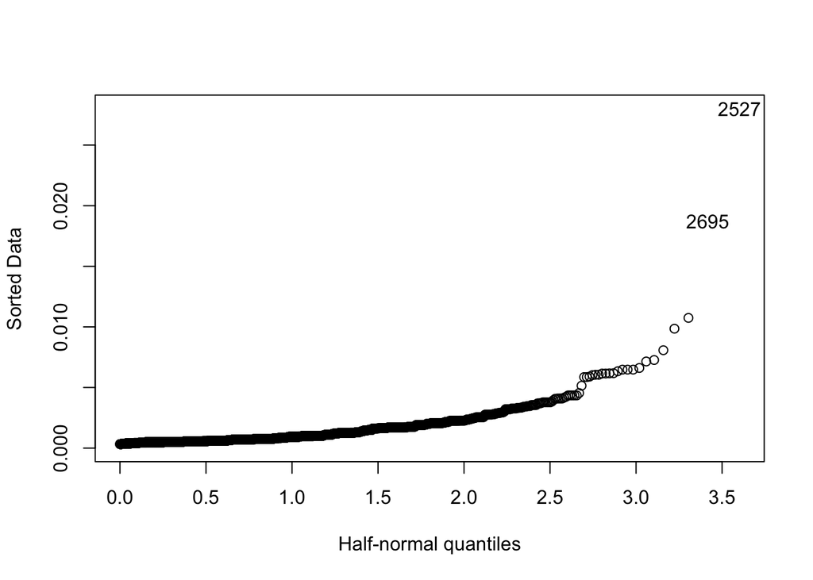

```r
halfnorm(hatvalues(lmod))
```

We see two high leverage cases, who smoke an unusual number of cigarettes per day!

```r
wcgs %>%
  slice(c(2527, 2695)) %>%
  print(width = Inf)
```

```
# A tibble: 2 × 13
    age height weight   sdp   dbp  chol behave  cigs dibep chd   typechd timechd
  <int>  <int>  <int> <int> <int> <int> <fct>  <int> <fct> <fct> <fct>     <int>
1    52     71    168   120    80   251 A1        99 A     no    none       2956
2    47     64    158   116    76   206 A1        80 A     no    none       2114
  arcus
  <fct>
1 present
2 absent
```

- Plot of Cook distance against half-normal quantiles may reveal high influential points (high residual combined with high leverage) cases.

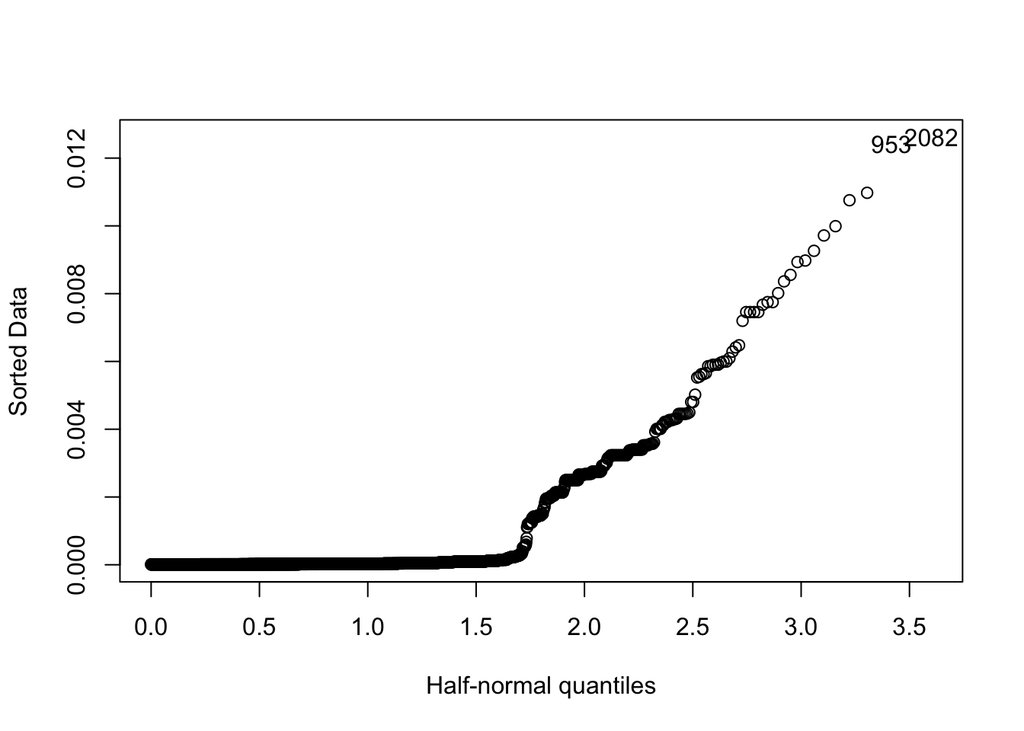

```r
halfnorm(cooks.distance(lmod))
```

```r
wcgs %>%
  slice(c(953, 2082)) %>%
  print(width = Inf)
```

```
# A tibble: 2 × 13
    age height weight   sdp   dbp  chol behave  cigs dibep chd   typechd timechd
  <int>  <int>  <int> <int> <int> <int> <fct>  <int> <fct> <fct> <fct>     <int>
1    57     63    155   128    88   196 A2         0 A     yes   silent     2349
2    49     77    210   138    86   235 B3         0 B     yes   angina     3048
  arcus
  <fct>
1 absent
2 absent
```

## 8 Goodness of fit

### 8.1 Hosmer-Lemeshow statistic

- Intuitively if we divide observations into $J$ bins according to linear predictors $\eta$, then $y_j / n_j$ (observed proportion of “successes”) for $j$-th bin should be close to the average predicted probabilities in that bin.

```r
wcgs_binned <- wcgs %>%
  mutate(predprob = predict(lmod, type = "response"),
         linpred  = predict(lmod, type = "link"),
         bin      = cut(linpred, breaks = unique(quantile(linpred, (1:100) / 101)))) %>%
  group_by(bin) %>%
  summarize(y       = sum(ifelse(chd == "yes", 1, 0)),
            avgpred = mean(predprob),
            count   = n()) %>%
  mutate(se_fit = sqrt(avgpred * (1 - avgpred) / count))
```

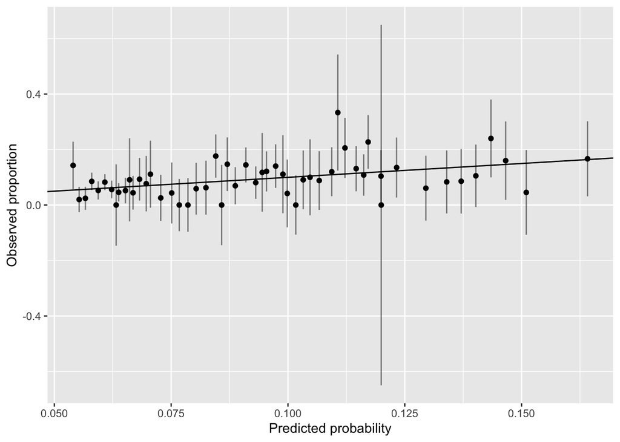

```r
wcgs_binned %>%
  ggplot(mapping = aes(x = avgpred, y = y / count)) +
  geom_point() +
  geom_linerange(mapping = aes(ymin = y / count - 2 * se_fit,
                               ymax = y / count + 2 * se_fit), alpha = 0.5) +
  geom_abline(intercept = 0, slope = 1) +
  labs(x = "Predicted probability", y = "Observed proportion")
```

- The Hosmer-Lemeshow test formalizes this idea by testing the statistic
  $$X_{\text{HL}}^2 = \sum_{j=1}^J \frac{(y_j - m_j \widehat{p}_j)^2}{m_j \widehat{p}_j (1 - \widehat{p}_j)}$$
  against the $\chi^2$ distribution with $J-1$ degrees of freedom.

```r
# Hosmer-Lemeshow test statistic
(hlstat <- with(wcgs_binned, sum((y - count * avgpred)^2 / (count * avgpred * (1 - avgpred)))))
```

```
[1] 64.84219
```

```r
# J
nrow(wcgs_binned)
```

```
[1] 53
```

```r
# p-value
pchisq(hlstat, nrow(wcgs_binned) - 1, lower.tail = FALSE)
```

```
[1] 0.108868
```

We see a moderate p-value, which indicates no lack of fit.

### 8.2 ROC curve

- Logistic regression is often used as a tool for **classification**.
- If we choose a threshold, say 0.2, then the predicted probabilities give a classification rule
  $$\text{case $i$ is a} \begin{cases}
  \text{"success"} & \text{if } \widehat{p}_i \ge 0.2 \\
  \text{"failure"} & \text{if } \widehat{p}_i < 0.2
  \end{cases}.$$

```r
wcgs %>%
  mutate(predprob = predict(lmod, type = "response")) %>%
  mutate(predout = ifelse(predprob >= 0.2, "yes", "no")) %>%
  xtabs(~ chd + predout, data = .)
```

```
     predout
chd     no  yes
  no  2886   11
  yes  254    3
```

- With this classification rule, we see the error rate is about

```r
(11 + 254) / (2886 + 254 + 11 + 3)
```

```
[1] 0.08402029
```

[figure not shown]

The **sensitivity** is
$$\frac{\text{TP}}{\text{TP + FN}} = \frac{3}{257} = 1.17\%$$
and the **specificity** is
$$\frac{\text{TN}}{\text{FP + TN}} = \frac{2886}{11 + 2886} = 99.62\%$$

- If we lower the threshold, then we increase the sensitivity but decrease the specificity. If we plot sensitivity against 1-specificity by varying the threshold, then we get the **receiver operating characteristic (ROC)** curve.

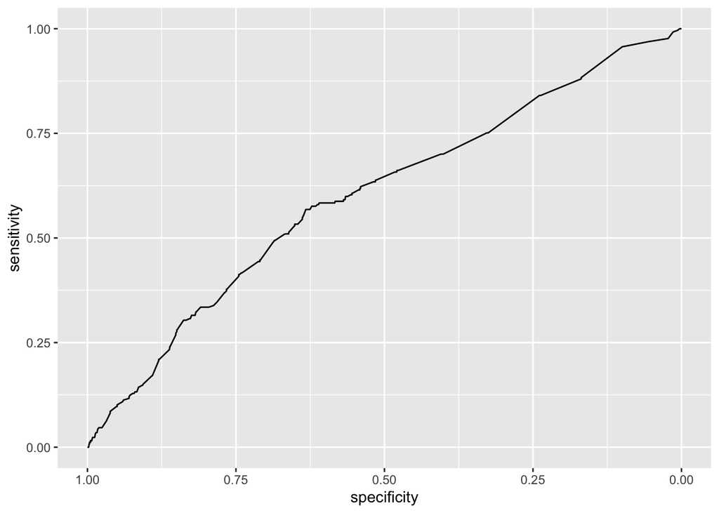

```r
library(pROC)
lmod_roc <- roc(chd ~ predprob, wcgs)
ggroc(lmod_roc)
```

The area under the curve (AUC) is a measure of the overal classification of the classifier. Larger AUC means better classification performance.

```r
auc(lmod_roc)
```

```
Area under the curve: 0.6007
```

## 9 Model selection by AIC

- We can perform sequential search using the Akaike information criterion (AIC)
  $$\text{AIC} = \text{deviance} + 2q.$$
  We start from a rich enough model

```r
wcgs <- wcgs %>%
  # 1 in = 0.0254 m, 1 lb = 0.4536 kg
  mutate(bmi = 703 * weight / height)
biglm <- glm(chd ~ age + height + weight + bmi + sdp + dbp + chol + dibep + cigs + arcus,
             family = binomial, data = wcgs)
```

and then do sequential backward search using the `step` function

```r
stats::step(biglm, trace = TRUE, direction = "back") %>%
  tbl_regression() %>%
  bold_labels()
```

```
Start:  AIC=1591.05
chd ~ age + height + weight + bmi + sdp + dbp + chol + dibep +
    cigs + arcus

         Df Deviance    AIC
- dbp     1   1569.1 1589.1
- weight  1   1569.3 1589.3
- bmi     1   1569.5 1589.5
- height  1   1569.5 1589.5
<none>        1569.0 1591.0
- arcus   1   1571.1 1591.1
- sdp     1   1576.8 1596.8
- dibep   1   1590.4 1610.4
- cigs    1   1592.0 1612.0
- age     1   1593.7 1613.7
- chol    1   1619.8 1639.8

Step:  AIC=1589.06
chd ~ age + height + weight + bmi + sdp + chol + dibep + cigs +
    arcus

         Df Deviance    AIC
- weight  1   1569.4 1587.4
- bmi     1   1569.5 1587.5
- height  1   1569.5 1587.5
<none>        1569.1 1589.1
- arcus   1   1571.2 1589.2
- sdp     1   1586.2 1604.2
- dibep   1   1590.4 1608.4
- cigs    1   1592.5 1610.5
- age     1   1593.7 1611.7
- chol    1   1619.9 1637.9

Step:  AIC=1587.36
chd ~ age + height + bmi + sdp + chol + dibep + cigs + arcus

         Df Deviance    AIC
- height  1   1570.3 1586.3
<none>        1569.4 1587.4
- arcus   1   1571.5 1587.5
- bmi     1   1574.4 1590.4
- sdp     1   1586.7 1602.7
- dibep   1   1590.7 1606.7
- cigs    1   1592.8 1608.8
- age     1   1594.0 1610.0
- chol    1   1620.0 1636.0

Step:  AIC=1586.32
chd ~ age + bmi + sdp + chol + dibep + cigs + arcus

        Df Deviance    AIC
<none>       1570.3 1586.3
- arcus  1   1572.6 1586.6
- bmi    1   1577.3 1591.3
- sdp    1   1587.2 1601.2
- dibep  1   1591.9 1605.9
- age    1   1594.2 1608.2
- cigs   1   1594.6 1608.6
- chol   1   1620.0 1634.0
```

| **Characteristic** | **log(OR)** | **95% CI** | **p-value** |
| --- | --- | --- | --- |
| age | 0.06 | 0.04, 0.08 | <0.001 |
| bmi | 0.00 | 0.00, 0.00 | 0.008 |
| sdp | 0.02 | 0.01, 0.03 | <0.001 |
| chol | 0.01 | 0.01, 0.01 | <0.001 |
| dibep |  |  |  |
| A | — | — |  |
| B | -0.66 | -0.95, -0.38 | <0.001 |
| cigs | 0.02 | 0.01, 0.03 | <0.001 |
| arcus |  |  |  |
| absent | — | — |  |
| present | 0.22 | -0.06, 0.50 | 0.13 |

Abbreviations: CI = Confidence Interval, OR = Odds Ratio

## 10 Model selection by lasso

- A modern approach for model selection is the **lasso**, which minimizes the function
  $$- n^{-1} \ell(\boldsymbol{\beta}) + \lambda \sum_{j=1}^q |\beta_j|,$$
  where $\ell(\boldsymbol{\beta})$ is the log-likelihood of logistic regression and $\lambda>0$ is a tuning parameter. We notice that
  - when $\lambda = \infty$, all non-intercept regression coefficients will be pushed to 0, and
  - when $\lambda = 0$, the regression coefficients are same as those from regular logistic regression.  
    If we vary $\lambda$ from 0 to larger values, we will obtain intermediate models with lesser and lesser preditors. This way we are achieving continuous model selection.
- For details of `glmnet` package, see the vignette at https://web.stanford.edu/~hastie/glmnet/glmnet_alpha.html
- How do we choose $\lambda$, which determines the model size? One natural idea is to split the data into a training set and a validation set. The **training set** is used to fit the logistic regression at different $\lambda$ values. Then the **validation set** is used to evaluate and compare the performance of different models. We will choose the model that gives the best performance on the validation set.
- First let’s remove cases with missing values

```r
(wcgs <- wcgs %>%
  select(-c(behave, typechd, timechd)) %>%
  drop_na())
```

```
# A tibble: 3,140 × 11
     age height weight   sdp   dbp  chol  cigs dibep chd   arcus     bmi
   <int>  <int>  <int> <int> <int> <int> <int> <fct> <fct> <fct>   <dbl>
 1    49     73    150   110    76   225    25 A     no    absent  1445.
 2    42     70    160   154    84   177    20 A     no    present 1607.
 3    42     69    160   110    78   181     0 B     no    absent  1630.
 4    41     68    152   124    78   132    20 B     no    absent  1571.
 5    59     70    150   144    86   255    20 B     yes   present 1506.
 6    44     72    204   150    90   182     0 B     no    absent  1992.
 7    44     72    164   130    84   155     0 B     no    absent  1601.
 8    40     71    150   138    60   140     0 A     no    absent  1485.
 9    43     72    190   146    76   149    25 B     no    absent  1855.
10    42     70    175   132    90   325     0 A     no    present 1758.
# ℹ 3,130 more rows
```

split data into 80% training cases and 20% validation cases.

```r
library(glmnet)
library(caret)
library(themis) # provides up/down-sampling methods for the data

# set seed for reproducibility
set.seed(200)

# list = FALSE, request result to be in a matrix (of row position) not a list
training_samples <- wcgs$chd %>%
  createDataPartition(p = 0.8, list = FALSE)
# (train_data <- wcgs %>%
#   slice(training_samples[, 1]))
# (val_data   <- wcgs %>%
#   slice(-training_samples[, 1]))
```

The `glmnet` package takes a matrix (of predictors) and a vector (of responses) as input. We use `model.matrix` function to create them. `glmnet` will add intercept by default, so we drop intercept term when forming `x` matrix.

```r
# X and y from original data
x_all <- model.matrix(
  chd ~ - 1 + age + height + weight + bmi + sdp + dbp + chol + dibep + cigs + arcus,
  data = wcgs)
y_all <- ifelse(wcgs$chd == "yes", 1, 0)
# training X and y
x_train <- x_all[training_samples[, 1], ]
y_train <- y_all[training_samples[, 1]]
# validation X and y
x_val <- x_all[-training_samples[, 1], ]
y_val <- y_all[-training_samples[, 1]]
```

Fit lasso regression and plot solution path:

```r
lasso_fit <- glmnet(x_train, y_train, family = "binomial", alpha = 1)
summary(lasso_fit)
```

```
           Length Class     Mode
a0          49    -none-    numeric
beta       539    dgCMatrix S4
df          49    -none-    numeric
dim          2    -none-    numeric
lambda      49    -none-    numeric
dev.ratio   49    -none-    numeric
nulldev      1    -none-    numeric
npasses      1    -none-    numeric
jerr         1    -none-    numeric
offset       1    -none-    logical
classnames   2    -none-    character
call         5    -none-    call
nobs         1    -none-    numeric
```

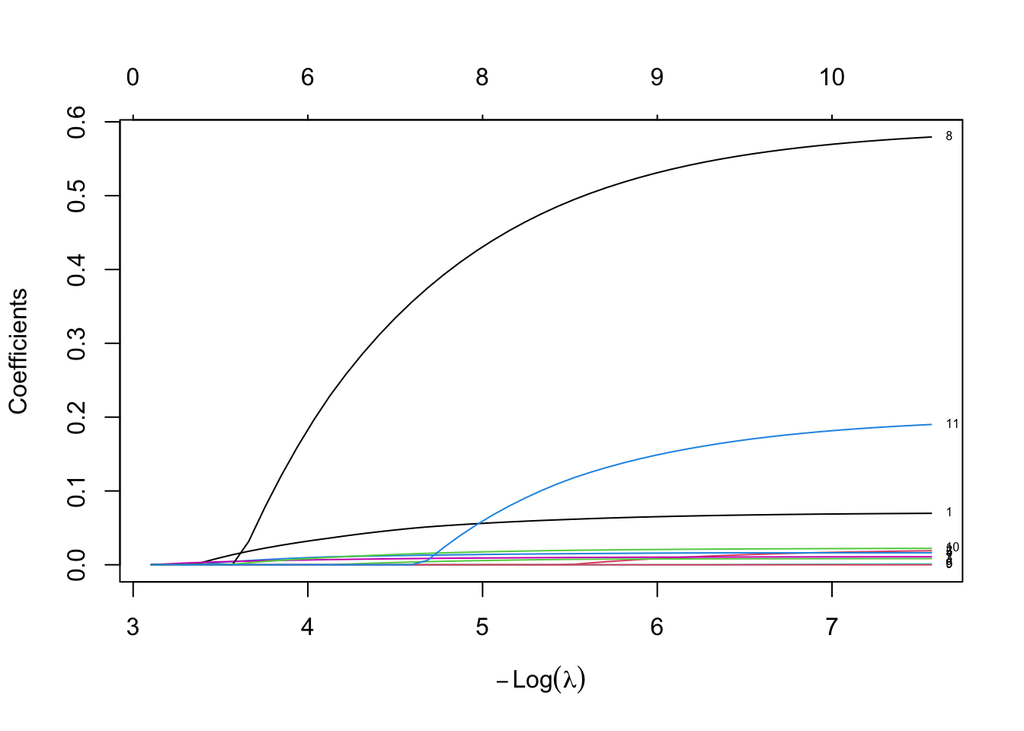

```r
plot(lasso_fit, xvar = "lambda", label = TRUE)
```

- Here
  - $\alpha = 1$ corresponds to the lasso regression, in the family of **elastic net penalties**
    $$(1 - \alpha) \|\boldsymbol{\beta}\|_2^2 / 2 + \alpha \|\boldsymbol{\beta}\|_1.$$
  - Other choises for `xvar` are `"lambda"` for log lambda value, `"norm"` for the $\ell_1$-norm of the coefficients (default), and `"dev"` for the percentage of deviance explained.
- Now we can evaluate the performance of the models (corresponding to different $\lambda$ values) on the validation set.

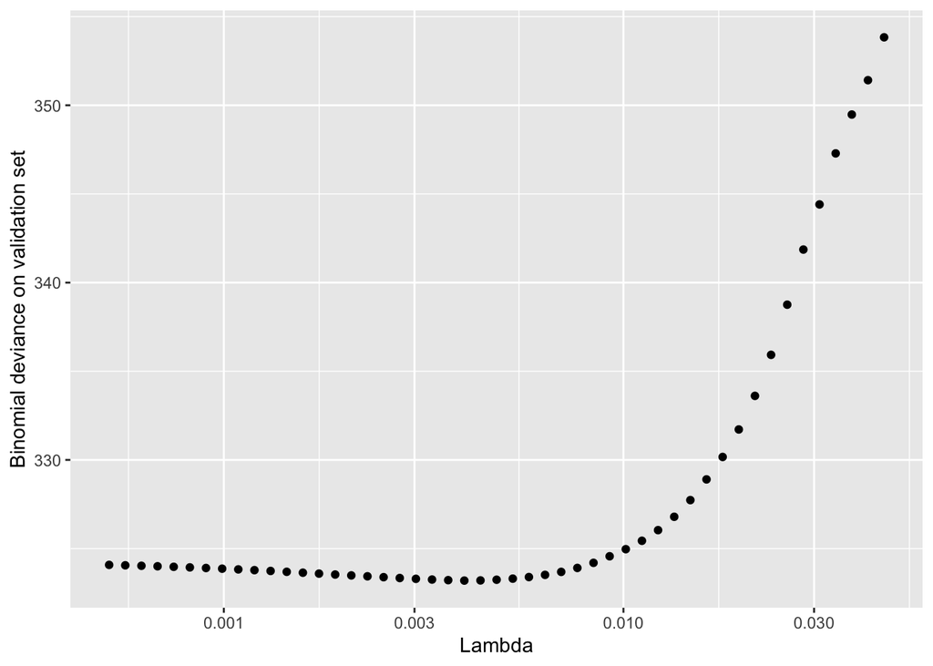

```r
# predict validation case probabilities at different \lambda values and calculate test deviance
pred_val <- predict(lasso_fit, newx = x_val, type = "response", s = lasso_fit$lambda)
dev_val <- -2 * colSums(y_val * log(pred_val) + (1 - y_val) * log(1 - pred_val))
tibble(lambda = lasso_fit$lambda, dev_val = dev_val) %>%
  ggplot() +
  geom_point(mapping = aes(x = lambda, y = dev_val)) +
  scale_x_log10() +
  labs(y = "Binomial deviance on validation set", x = "Lambda")
```

From the graph, it seems that $\lambda = 0.005$ yields a model that performs best on the validation set.

- Now the question is whether we should make decision on this single training-validation split? A common strategy is to use **cross validation**.

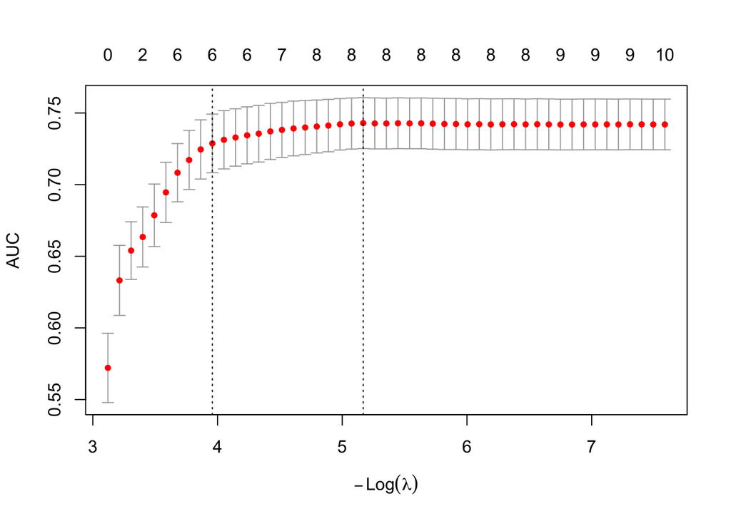

```r
set.seed(200)
cv_lasso <- cv.glmnet(x_all, y_all, alpha = 1, family = "binomial",
                      type.measure = "auc")
plot(cv_lasso)
```

```r
cv_lasso$lambda.min
```

```
[1] 0.005696827
```

```r
coef(cv_lasso, cv_lasso$lambda.min)
```

```
12 x 1 sparse Matrix of class "dgCMatrix"
             s=0.005696827
(Intercept)  -1.040951e+01
age           4.954011e-02
height        .
weight        5.334625e-03
bmi           .
sdp           1.537576e-02
dbp           .
chol          9.228292e-03
dibepA        5.162308e-01
dibepB       -5.494421e-15
cigs          1.656021e-02
arcuspresent  9.149817e-02
```

We see that this model differs from the best model chosen by AIC by replacing the predictor `bmi` by `weight`.

### 10.1 Try `tidymodels`

- Dig deeper into tidy modeling with R at https://www.tmwr.org
- Machine Learning Workflow: Lasso Regression qmd, html

```r
library(tidymodels)
```

```r
# For reproducibility
set.seed(203)

data_split <- initial_split(
  wcgs,
  # stratify by chd
  strata = "chd",
  prop = 0.75)

data_split
```

```
<Training/Testing/Total>
<2355/785/3140>
```

```r
wcgs_other <- training(data_split)
dim(wcgs_other)
```

```
[1] 2355   11
```

```r
wcgs_test <- testing(data_split)
dim(wcgs_test)
```

```
[1] 785  11
```

- Receipt https://recipes.tidymodels.org/articles/recipes.html#preprocessing-steps

```r
logit_recipe <-
  recipe(
    chd ~  age + height + weight + bmi + sdp + dbp + chol + dibep + cigs + arcus,
    data = wcgs_other
  ) %>%
  # mean imputation for chol
  step_impute_mean(chol) %>%
  # mode imputation for arcus
  step_impute_mode(arcus) %>%
  # create traditional dummy variables
  step_dummy(all_nominal_predictors()) %>%
  # zero-variance filter
  step_zv(all_numeric_predictors()) %>%
  # center and scale numeric data
  step_normalize(all_numeric_predictors()) # %>%
  # estimate the means and standard deviations
  # prep(training = wcgs_other, retain = TRUE)
logit_recipe
```

- Model

```r
logit_mod <-
  logistic_reg(
    penalty = tune(),
    mixture = 1 # tune()
  ) %>%
  set_engine("glmnet", standardize = FALSE)
logit_mod
```

```
Logistic Regression Model Specification (classification)

Main Arguments:
  penalty = tune()
  mixture = 1

Engine-Specific Arguments:
  standardize = FALSE

Computational engine: glmnet
```

- Workflow

```r
logit_wf <- workflow() %>%
  add_recipe(logit_recipe) %>%
  add_model(logit_mod)
logit_wf
```

```
══ Workflow ════════════════════════════════════════════════════════════════════
Preprocessor: Recipe
Model: logistic_reg()

── Preprocessor ────────────────────────────────────────────────────────────────
5 Recipe Steps

• step_impute_mean()
• step_impute_mode()
• step_dummy()
• step_zv()
• step_normalize()

── Model ───────────────────────────────────────────────────────────────────────
Logistic Regression Model Specification (classification)

Main Arguments:
  penalty = tune()
  mixture = 1

Engine-Specific Arguments:
  standardize = FALSE

Computational engine: glmnet
```

- Tuning grid

```r
param_grid <- grid_regular(
  penalty(range = c(-6, 3)),
  # mixture(),
  levels = 100 # c(100, 5)
  )
param_grid
```

```
# A tibble: 100 × 1
      penalty
        <dbl>
 1 0.000001
 2 0.00000123
 3 0.00000152
 4 0.00000187
 5 0.00000231
 6 0.00000285
 7 0.00000351
 8 0.00000433
 9 0.00000534
10 0.00000658
# ℹ 90 more rows
```

- Cross validation

```r
# Set cross-validation partitions
set.seed(200)

folds <- vfold_cv(wcgs_other, v = 5)
folds
```

```
#  5-fold cross-validation
# A tibble: 5 × 2
  splits             id
  <list>             <chr>
1 <split [1884/471]> Fold1
2 <split [1884/471]> Fold2
3 <split [1884/471]> Fold3
4 <split [1884/471]> Fold4
5 <split [1884/471]> Fold5
```

- Fit cross-validation

```r
system.time({
logit_fit <- logit_wf %>%
  tune_grid(
    resamples = folds,
    grid = param_grid,
    metrics = metric_set(roc_auc, accuracy)
    )
})
```

```
   user  system elapsed
 19.787   0.078  19.882
```

```r
logit_fit
```

```
# Tuning results
# 5-fold cross-validation
# A tibble: 5 × 4
  splits             id    .metrics           .notes
  <list>             <chr> <list>             <list>
1 <split [1884/471]> Fold1 <tibble [200 × 5]> <tibble [0 × 4]>
2 <split [1884/471]> Fold2 <tibble [200 × 5]> <tibble [0 × 4]>
3 <split [1884/471]> Fold3 <tibble [200 × 5]> <tibble [0 × 4]>
4 <split [1884/471]> Fold4 <tibble [200 × 5]> <tibble [0 × 4]>
5 <split [1884/471]> Fold5 <tibble [200 × 5]> <tibble [0 × 4]>
```

```
# A tibble: 200 × 7
      penalty .metric  .estimator  mean     n std_err .config
        <dbl> <chr>    <chr>      <dbl> <int>   <dbl> <chr>
 1 0.000001   accuracy binary     0.921     5 0.00489 pre0_mod001_post0
 2 0.000001   roc_auc  binary     0.739     5 0.0240  pre0_mod001_post0
 3 0.00000123 accuracy binary     0.921     5 0.00489 pre0_mod002_post0
 4 0.00000123 roc_auc  binary     0.739     5 0.0240  pre0_mod002_post0
 5 0.00000152 accuracy binary     0.921     5 0.00489 pre0_mod003_post0
 6 0.00000152 roc_auc  binary     0.739     5 0.0240  pre0_mod003_post0
 7 0.00000187 accuracy binary     0.921     5 0.00489 pre0_mod004_post0
 8 0.00000187 roc_auc  binary     0.739     5 0.0240  pre0_mod004_post0
 9 0.00000231 accuracy binary     0.921     5 0.00489 pre0_mod005_post0
10 0.00000231 roc_auc  binary     0.739     5 0.0240  pre0_mod005_post0
# ℹ 190 more rows
```

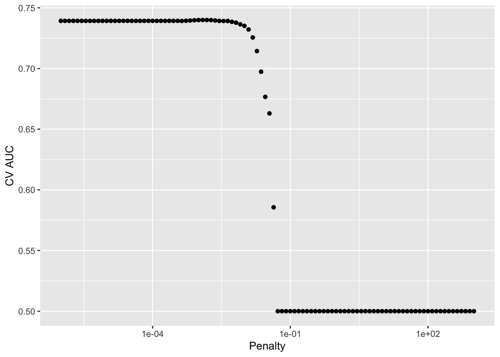

```r
logit_fit %>%
  collect_metrics() %>%
  print(width = Inf) %>%
  filter(.metric == "roc_auc") %>%
  ggplot(mapping = aes(x = penalty, y = mean)) +
  geom_point() +
  labs(x = "Penalty", y = "CV AUC") +
  scale_x_log10()
```

```r
best_logit <- logit_fit %>%
  select_best(metric = "roc_auc")
best_logit
```

```
# A tibble: 1 × 2
  penalty .config
    <dbl> <chr>
1 0.00123 pre0_mod035_post0
```

### 10.2 Finalize model

- Final workflow

```r
final_wf <- logit_wf %>%
  finalize_workflow(best_logit)
final_wf
```

```
══ Workflow ════════════════════════════════════════════════════════════════════
Preprocessor: Recipe
Model: logistic_reg()

── Preprocessor ────────────────────────────────────────────────────────────────
5 Recipe Steps

• step_impute_mean()
• step_impute_mode()
• step_dummy()
• step_zv()
• step_normalize()

── Model ───────────────────────────────────────────────────────────────────────
Logistic Regression Model Specification (classification)

Main Arguments:
  penalty = 0.00123284673944207
  mixture = 1

Engine-Specific Arguments:
  standardize = FALSE

Computational engine: glmnet
```

```r
# Fit the whole training set, then predict the test cases
final_fit <-
  final_wf %>%
  last_fit(data_split)
final_fit
```

```
# Resampling results
# Manual resampling
# A tibble: 1 × 6
  splits             id               .metrics .notes   .predictions .workflow
  <list>             <chr>            <list>   <list>   <list>       <list>
1 <split [2355/785]> train/test split <tibble> <tibble> <tibble>     <workflow>
```

```r
# Test metrics
final_fit %>%
  collect_metrics()
```

```
# A tibble: 3 × 4
  .metric     .estimator .estimate .config
  <chr>       <chr>          <dbl> <chr>
1 accuracy    binary        0.910  pre0_mod0_post0
2 roc_auc     binary        0.758  pre0_mod0_post0
3 brier_class binary        0.0770 pre0_mod0_post0
```

- Selected variables’ coefficients

```r
tidy(extract_fit_engine(final_fit)) %>%
  filter(lambda > 0.001 & lambda < 0.0011)
```

```
# A tibble: 9 × 5
  term           step estimate  lambda dev.ratio
  <chr>         <dbl>    <dbl>   <dbl>     <dbl>
1 (Intercept)      41  -2.80   0.00106     0.109
2 age              41   0.293  0.00106     0.109
3 height           41  -0.0209 0.00106     0.109
4 bmi              41   0.216  0.00106     0.109
5 sdp              41   0.217  0.00106     0.109
6 chol             41   0.471  0.00106     0.109
7 cigs             41   0.290  0.00106     0.109
8 dibep_B          41  -0.294  0.00106     0.109
9 arcus_present    41   0.118  0.00106     0.109
```